# Zadanie domowe - EDA Danych dotyczących Irysów

- Twoim zadaniem jest wykonanie analizy danych zawartych w załączonym pliku CSV (`25__iris.csv`).
- Plik znajduje się pod video. Pamiętaj, żeby wrzucić plik do tego samego folderu, w którym znajduje się ten notebook.
- Wykorzystaj nowo nabytą wiedzę z biblioteki `Pandas`
- Jeżeli jest taka konieczność posiłkuj się [code explainerem](https://codeexplainer.imprv.ai/) lub / i [data chatterem](https://datachatter.imprv.ai/) (który również te dane ma dostępne).
- Prześlij na discordzie notebook z rozwiązaniem (`#modul-4-zad1`)
- Pamiętaj:
1. Nie spiesz się
2. Potraktuj zadanie domowe jak prawdziwy projekt
3. Dodawaj opisy, obserwacje, wnioski
4. Dodaj wizualizacje
5. Dodaj konkluzję i wnioski końcowe

Powodzenia!!! I mega zabawy!

## O Danych

Zbiór danych zawiera informacje o trzech gatunkach irysów: Iris setosa, Iris versicolor, i Iris virginica.

Dane obejmują pomiary czterech cech: długość i szerokość działki kielicha oraz długość i szerokość płatka.

Każdy wiersz w zbiorze danych reprezentuje pojedynczy kwiat, a wartości pomiarów są podane w centymetrach.

Zbiór składa się z 150 próbek, po 50 dla każdego gatunku, i jest szeroko stosowany jako podstawowy zbiór danych do testowania algorytmów klasyfikacji oraz w nauce o danych i uczeniu maszynowym.

Kolumny:

- **długość kielicha (sepal length)** - Długość kielicha w cm
- **szerokość kielicha (sepal width)** - Szerokość kielicha w cm
- **długość płatka (petal length)** - Długość płatka w cm
- **szerokość płatka (petal width)** - Szerokość płatka w cm
- **klasa (class)** - Klasa irysa (setosa, versicolor, virginica)

## ANALIZA

```python
import pandas as pd
import matplotlib.pyplot as plt
import seaborn as sns
```

```python
df = pd.read_csv('25__iris.csv', sep=",")
df.sample(10)
```

|  | długość kielicha (sepal length) | szerokość kielicha (sepal width) | długość płatka (petal length) | szerokość płatka (petal width) | klasa (class) |
| --- | --- | --- | --- | --- | --- |
| 17 | 5.1 | 3.5 | 1.4 | 0.3 | Iris-setosa |
| 139 | 6.9 | 3.1 | 5.4 | 2.1 | Iris-virginica |
| 93 | 5.0 | 2.3 | 3.3 | 1.0 | Iris-versicolor |
| 29 | 4.7 | 3.2 | 1.6 | 0.2 | Iris-setosa |
| 51 | 6.4 | 3.2 | 4.5 | 1.5 | Iris-versicolor |
| 112 | 6.8 | 3.0 | 5.5 | 2.1 | Iris-virginica |
| 87 | 6.3 | 2.3 | 4.4 | 1.3 | Iris-versicolor |
| 95 | 5.7 | 3.0 | 4.2 | 1.2 | Iris-versicolor |
| 45 | 4.8 | 3.0 | 1.4 | 0.3 | Iris-setosa |
| 149 | 5.9 | 3.0 | 5.1 | 1.8 | Iris-virginica |

```python
df.info()
df.describe()
```

```
<class 'pandas.core.frame.DataFrame'>
RangeIndex: 150 entries, 0 to 149
Data columns (total 5 columns):
 #   Column                            Non-Null Count  Dtype
---  ------                            --------------  -----
 0   długość kielicha (sepal length)   150 non-null    float64
 1   szerokość kielicha (sepal width)  150 non-null    float64
 2   długość płatka (petal length)     150 non-null    float64
 3   szerokość płatka (petal width)    150 non-null    float64
 4   klasa (class)                     150 non-null    object
dtypes: float64(4), object(1)
memory usage: 6.0+ KB
```

|  | długość kielicha (sepal length) | szerokość kielicha (sepal width) | długość płatka (petal length) | szerokość płatka (petal width) |
| --- | --- | --- | --- | --- |
| count | 150.000000 | 150.000000 | 150.000000 | 150.000000 |
| mean | 5.843333 | 3.054000 | 3.758667 | 1.198667 |
| std | 0.828066 | 0.433594 | 1.764420 | 0.763161 |
| min | 4.300000 | 2.000000 | 1.000000 | 0.100000 |
| 25% | 5.100000 | 2.800000 | 1.600000 | 0.300000 |
| 50% | 5.800000 | 3.000000 | 4.350000 | 1.300000 |
| 75% | 6.400000 | 3.300000 | 5.100000 | 1.800000 |
| max | 7.900000 | 4.400000 | 6.900000 | 2.500000 |

```python
# skracamy nazwy kolumn
df.columns = ["dl.kielicha", "szer.kielicha", "dl.platka", "szer.platka", "klasa"]
```

```python
df.nunique()
```

```
dl.kielicha      35
szer.kielicha    23
dl.platka        43
szer.platka      22
klasa             3
dtype: int64
```

```python
df["klasa"].value_counts()
```

```
Iris-setosa        50
Iris-versicolor    50
Iris-virginica     50
Name: klasa, dtype: int64
```

```python
df.isnull().sum()
```

```
dl.kielicha      0
szer.kielicha    0
dl.platka        0
szer.platka      0
klasa            0
dtype: int64
```

Posiadamy dane dla 150 próbek irysów, po 50 dla każdego z trzech gatunków: Iris-setosa, Iris-versicolor, i Iris-virginica. Możemy zauważyć, że dane są kompletne, nie występują braki wartości.

```python
df.groupby("klasa").mean()
```

| klasa | dl.kielicha | szer.kielicha | dl.platka | szer.platka |
| --- | --- | --- | --- | --- |
| Iris-setosa | 5.006 | 3.418 | 1.464 | 0.244 |
| Iris-versicolor | 5.936 | 2.770 | 4.260 | 1.326 |
| Iris-virginica | 6.588 | 2.974 | 5.552 | 2.026 |

```python
df.groupby("klasa").median()
```

| klasa | dl.kielicha | szer.kielicha | dl.platka | szer.platka |
| --- | --- | --- | --- | --- |
| Iris-setosa | 5.0 | 3.4 | 1.50 | 0.2 |
| Iris-versicolor | 5.9 | 2.8 | 4.35 | 1.3 |
| Iris-virginica | 6.5 | 3.0 | 5.55 | 2.0 |

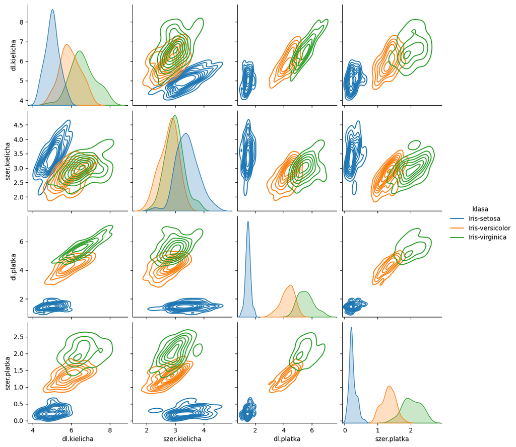

```python
sns.pairplot(df, hue="klasa", kind="kde", )
```

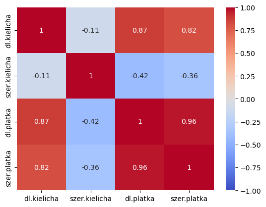

```python
corr_matrix = df.iloc[:,:-1].corr()
sns.heatmap(corr_matrix, annot=True, cmap="coolwarm", vmin=-1, vmax=1)
```

W całym zbiorze widzimy wyraźną korelację dodatnią między długością i szerokością płatka oraz nieco mniejsze kerelacje między długością i szerokością płatka a długością kielicha.

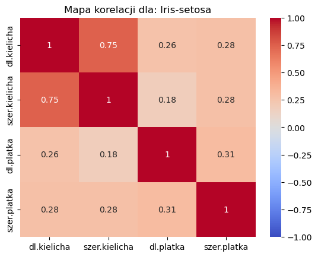

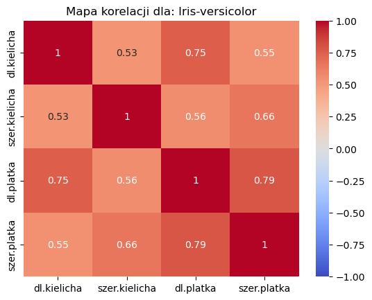

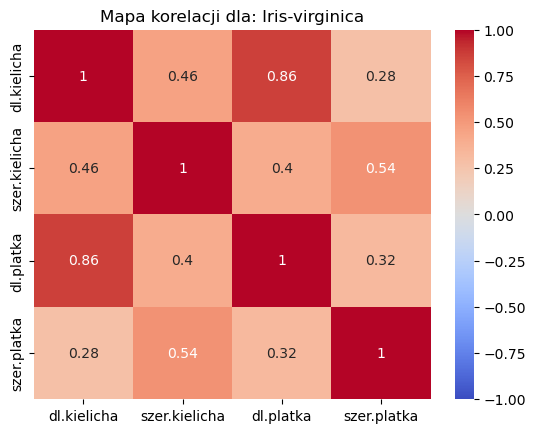

```python
klasy = df["klasa"].unique()

for klasa in klasy:
    plt.figure()
    subset = df[df["klasa"] == klasa]
    corr_matrix = subset.drop(columns="klasa").corr()
    sns.heatmap(corr_matrix, annot=True, cmap="coolwarm", vmin=-1, vmax=1)
    plt.title(f"Mapa korelacji dla: {klasa}")
    plt.show()
    plt.close()
```

Ciekawostką jest, że tak duże korelacje jak w całymłym zbiorze, nie występują w zakresie poszczególnych gatunków. Wyraźna jest korelacja między dłgością płatka a długością kielicha w przypadku gatunku Iris-virginica.

```
dl.kielicha         Axes(0.125,0.53;0.352273x0.35)
dl.platka        Axes(0.547727,0.53;0.352273x0.35)
szer.kielicha       Axes(0.125,0.11;0.352273x0.35)
szer.platka      Axes(0.547727,0.11;0.352273x0.35)
dtype: object
```

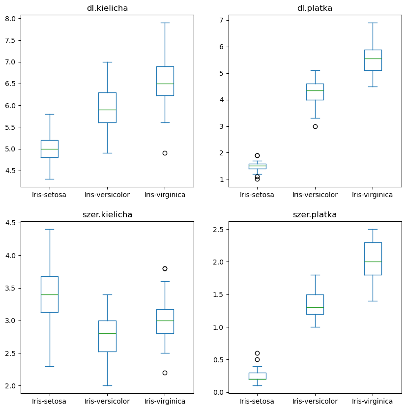

```python
df.plot(kind="box", by="klasa", layout=(2,2), figsize=(10,10))
```

Na wykresach możemy zauważyć, że jesteśmy w stanie rozróżnić poszczególne gatunki na podstawie wielkośkości ich cech. Najbardzieziej wyraźne jest to w przypadku Iris-setosa, którego płatki są są znacznie mniejsze niż u pozostałych dwóch gatunków a jego kielich jest krótki i szeroki. W tym gatunku najczęściej także występują odstające wartości wielkościsci płatków, jednakże wciąż są mniejsze od pozostałych gatunków.

W przypadku Iris-versicolor i Iris-virginica różnice nie są tak zauważalne, ale nadal można je rozróżnić na podstawie długości kielicha i wielkości płatków. Iris-virginica ma nieco dłuższy kielich i dłuższe i szersze płatki niż Iris-versicolor.

## KONKLUZJA

Na podstawie analizy danych możemy stwierdzić, że możemy rozróżnić poszczególne gatunki irysów na podstawie ich cech.

- **Iris-setosa** jest łatwo rozróżnialny od pozostałych dwóch gatunków, jest znacznie mniejszy.
- **Iris-versicolor** i **Iris-virginica** różnice nie są tak zauważalne, ale nadal można je rozróżnić na podstawie długości kielicha i wielkości płatków. Iris-virginica ma nieco dłuższy kielich oraz dłuższe i szersze płatki od Iris-versicolor.

Jednakże należy pamiętać, że analiza ta jest oparta na danych, które mamy do dyspozycji. Dostarczona próbka jest stosunkowo mała (50 próbek dla każdego gatunku), więc wyniki mogą być nieco ograniczone. Aby uzyskać bardziej pewne wyniki, należałoby przeprowadzić analizę na większej próbce danych. Nie wiemy także nic o sposobie pomiaru cech irysów: czy były wykonywane w warunkach kontrolowanych na jednej hodowli, czy kwiatostan był w jednakowej fazie rozwoju itd.